# Reproducible Research: Peer Assessment 1

## Loading and preprocessing the data

```r
rawdata <- read.csv("activity.csv")
cleandata <- subset(rawdata, complete.cases(rawdata))
```

## What is mean total number of steps taken per day?

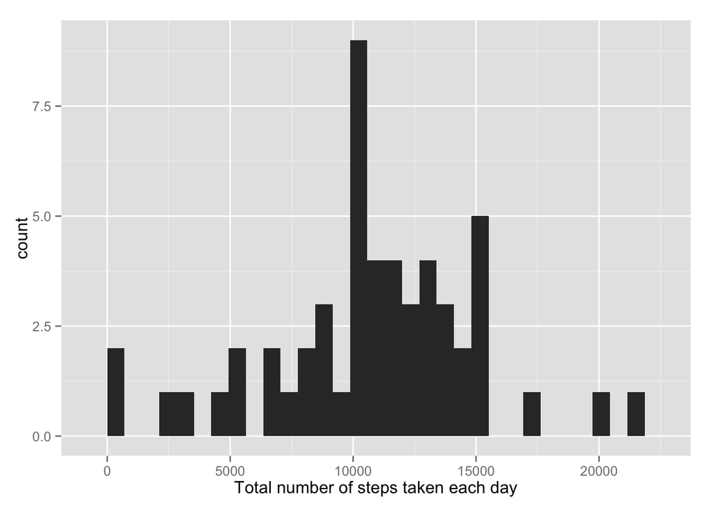

```r
### "Make a histogram of the total number of steps taken each day" *quote from assignment
### take the default binwidth that is range/30 (to skip warning message)
m <- tapply(cleandata$steps, cleandata$date, sum)
m <- m[ !is.na(m) ]
library(ggplot2)
qplot( m, binwidth = (max(m)-min(m))/30, xlab = "Total number of steps taken each day" )
```

```r
### "Calculate and report the mean and median total number of steps taken per day" *quote from assignment
smean <- mean( m )
smedian <- median( m )
```

The **mean** of total number of steps taken per day is **10766.1886792453**.  
and **median** of total number of steps taken per day is **10765**.

## What is the average daily activity pattern?

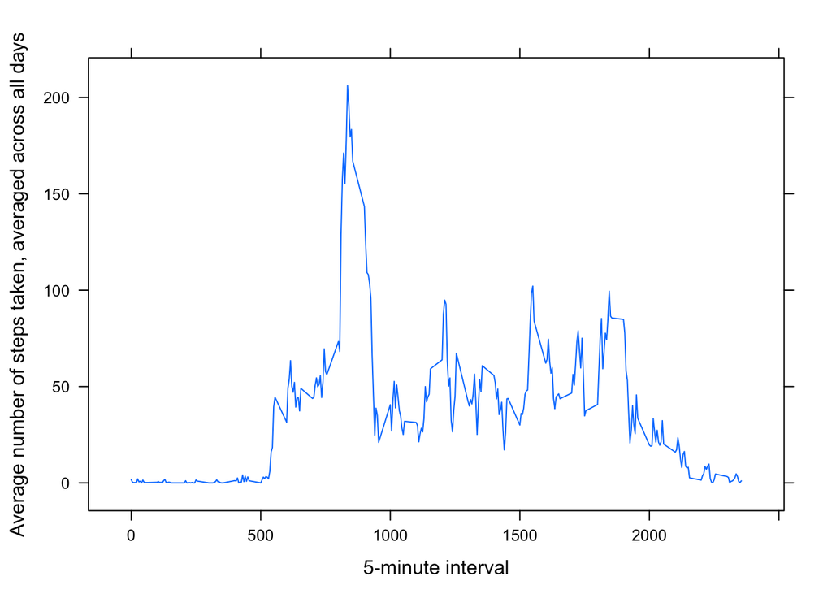

```r
### "Make a time series plot (i.e. type = "l") of the 5-minute interval (x-axis) and the average number of steps taken, averaged across all days (y-axis)" *quote from assignment
p <- tapply(cleandata$steps, cleandata$interval, mean)
p <- p[ !is.na(p) ]
library(lattice)
xyplot(p ~ as.numeric(names(p)), type = "l", xlab = "5-minute interval", ylab = "Average number of steps taken, averaged across all days" )
```

```r
### "Which 5-minute interval, on average across all the days in the dataset, contains the maximum number of steps?"
max_int <- names( p[ p == max( p ) ])
```

The 5-minute interval number **835** contains the maximum number of steps on average across all the days in the dataset

## Imputing missing values

```r
### "Calculate and report the total number of missing values in the dataset (i.e. the total number of rows with NAs)" *quote from assignment
na_no <- nrow(rawdata) - nrow(cleandata)
```

The total number of missing values in the dataset (i.e. the total number of rows with NAs) is **2304**

```r
### "Create a new dataset that is equal to the original dataset but with the missing data filled in." *quote from assignment."

restoreddata <- rawdata
for (k in 1:nrow(restoreddata)) {
        if ( is.na( restoreddata[k,"steps"] ) ) {
                restoreddata[k,"steps"] <- p[ as.character( restoreddata[k,"interval"] ) ]
        }
}
```

### A histogram of the dataset with the missing data filled in by the average values per interval on average across all the days in the dataset

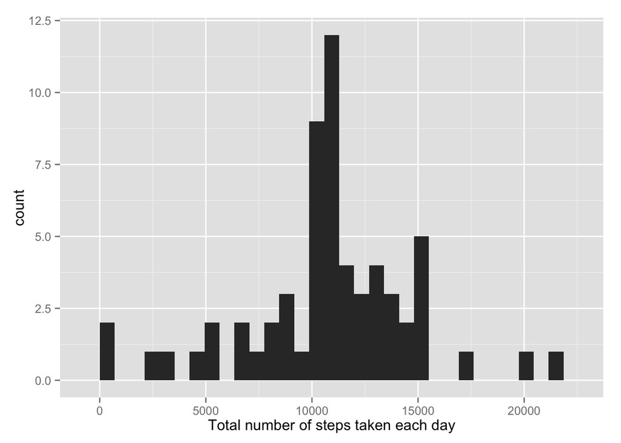

```r
### "Make a histogram of the total number of steps taken each day" *quote from assignment

m_new <- tapply(restoreddata$steps, restoreddata$date, sum)
m_new <- m_new[ !is.na(m) ]
library(ggplot2)
qplot( m_new, binwidth = (max(m_new)-min(m_new))/30, xlab = "Total number of steps taken each day" )
```

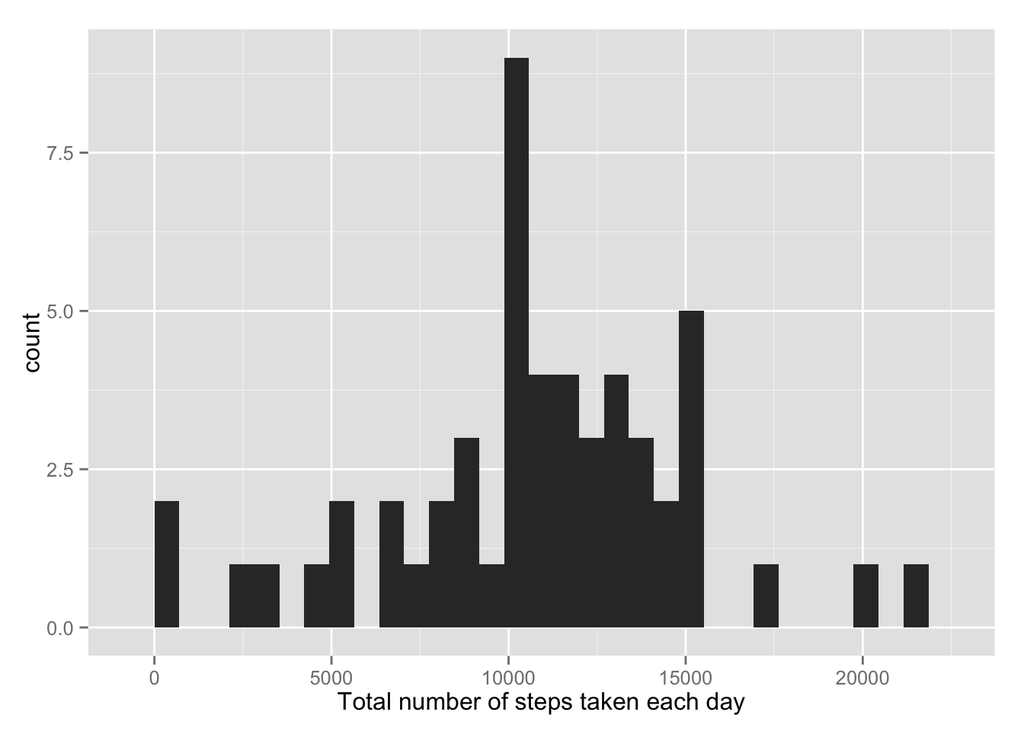

```r
qplot( m, binwidth = (max(m)-min(m))/30, xlab = "Total number of steps taken each day" )
```

```r
### "Calculate and report the mean and median total number of steps taken per day" *quote from assignment
smean_new <- mean( m_new )
smedian_new <- median( m_new )
dif_mean <- smean - smean_new
dif_median <- smedian - smedian_new
```

The **mean** of total number of steps taken per day is **10766.1886792453**.  
and **median** of total number of steps taken per day is **10766.1886792453**.

```r
### "Do these values differ from the estimates from the first part of the assignment? What is the impact of imputing missing data on the estimates of the total daily number of steps?" *quote from assignment" *quote from assignment
```

The **mean** of total number of steps taken per day (from the estimates from the first part of the assignment) was **10766.1886792453**, the same figure with the restored NAs by average numbers is **10766.1886792453**.  
The **median** of total number of steps taken per day (from the estimates from the first part of the assignment) was **10765**, the same figure with the restored NAs by average numbers is **10766.1886792453**.

The impact (difference) in **mean** value is **0** and in **median** is **-1.1886792452824**.

## Are there differences in activity patterns between weekdays and weekends?

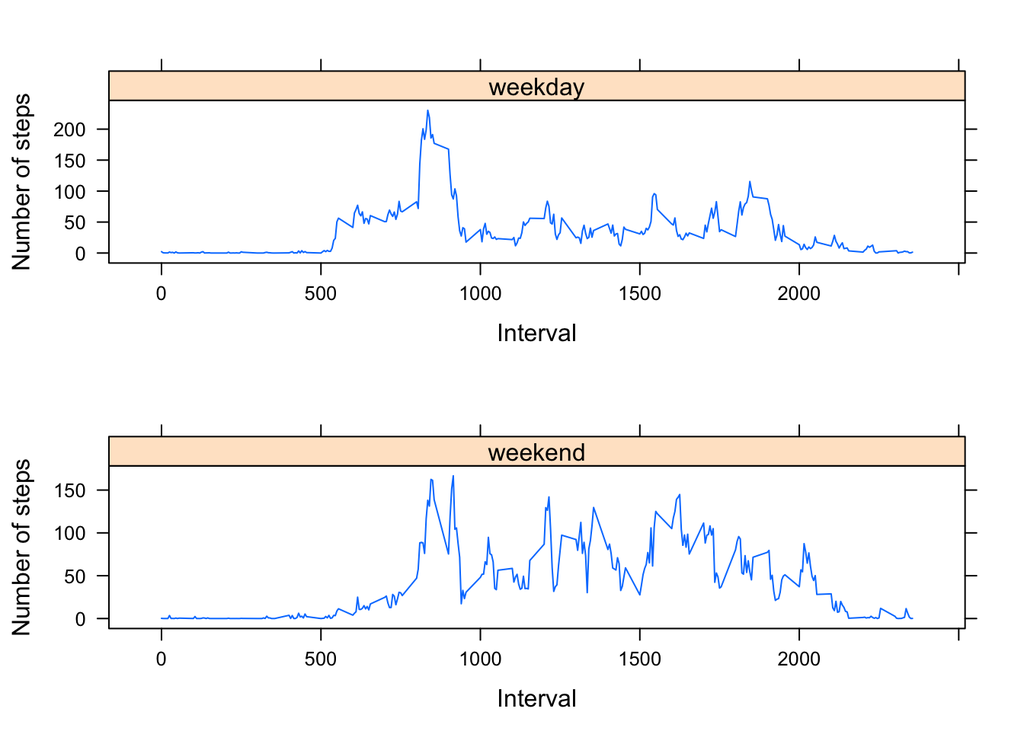

```r
weekdata <- transform(restoreddata, weekdayff = as.POSIXlt(as.Date(restoreddata$date))$wday)
for (z in 1:nrow(weekdata)) weekdata$weekdayff[z] <- if (weekdata$weekdayff[z] %in% c(0,6)) "weekend" else "weekday"

plot1 <- xyplot(as.numeric(tapply(steps, interval, mean)) ~ as.numeric(interval) | weekdayff, data = subset(weekdata, weekdata$weekday == "weekday"), type = "l", xlab = "Interval", ylab = "Number of steps" )

plot2 <- xyplot(as.numeric(tapply(steps, interval, mean)) ~ as.numeric(interval) | weekdayff, data = subset(weekdata, weekdata$weekday == "weekend"), type = "l", xlab = "Interval", ylab = "Number of steps" )

library(gridExtra)
grid.arrange(plot1,plot2, nrow=2)
```